- Group Information
- Differential Analysis
- Annotation of Peaks

# Azenta ChIP-seq Differential Peaks Report

## 1. Group Information

| Customer | Anders Ohman |
| --- | --- |
| Email | anders_ohman@brown.edu |
| QuoteNumber | 30-748712749 |
| Configuration |  |
| Control | Fetal-LAP-2m1 |
| Experiment | Fetal-Dual-2m1 |

## 2. Differential Peak Analysis

Peaks identified in each condition were merged and the resulting consensus peaks were used exclusively for differential peak analyses. Reads aligning to consensus peaks were counted in all samples.

| Sample | Number of Peaks |
| --- | --- |
| Fetal-LAP-2m1 | 200 |
| Fetal-Dual-2m1 | 32 |
| Merged | 206 |

### 2.1 Hierarchical clustering analysis

Read counts in merged peaks were used to calculate distances between samples and a heatmap of sample-to-sample relationships was generated.

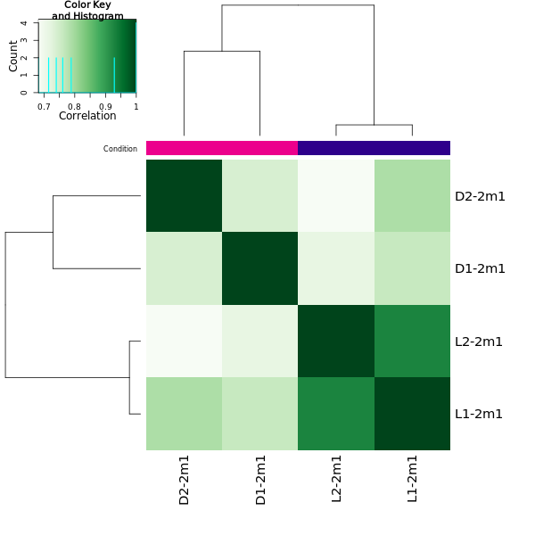

Hierarchical clustering of samples

### 2.2 Differential Binding Analysis

The R package DiffBind was used for differential region of interest (ROI) detection using an FDR <= 0.05 as a cutoff. Peaks with a fold-change below zero and an FDR <= 0.05 indicate regions with lower accessibility. Peaks with a fold change greater than zero and an FDR <= 0.05 indicate regions with higher accessibility.

| Sample | Number of Peaks |
| --- | --- |
| Total | 23 |
| Lower Affinity | 10 |
| Higher Affinity | 13 |

## 3. Annotation of Peaks

### 3.1 Average ChIP-seq Profile at annotated transcription start sites (TSS’s)

Figure 3.1 shows the average profile of ChIP-seq peaks falling within +/- 3Kb of annotated TSS sites genome-wide.  
This profile indicates whether called peaks are enriched around promoters.

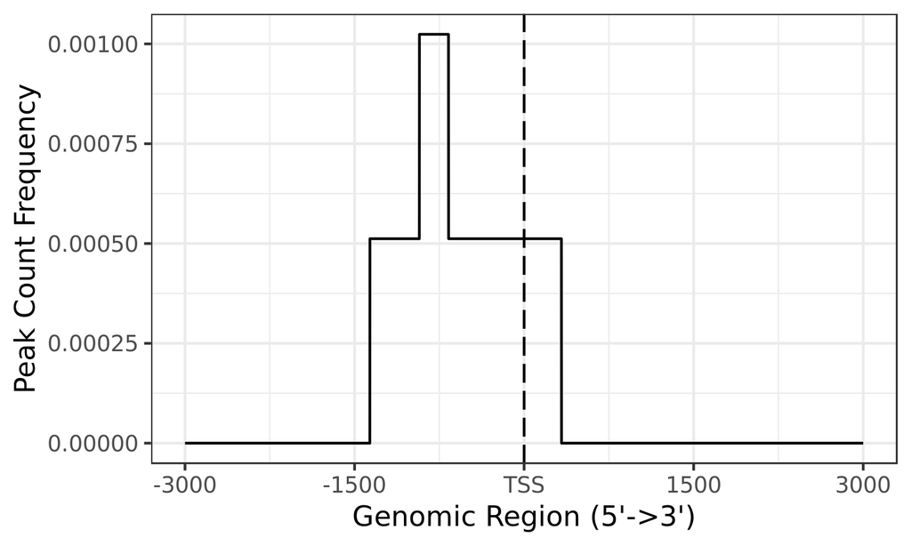

Figure 3.1 Average peak profile within +/- 3Kb of annotated TSS’s

### 3.2 Differential Peak Annotation

Peaks were annotated based on the genomic features they overlap. When annotations overlap assignment priorities are: Promoter > 5’UTR > 3’UTR > Exon > Intron > Downstream > Intergenic.

Figure 3.2 Composition of peak overlaps with annotated genomic features.

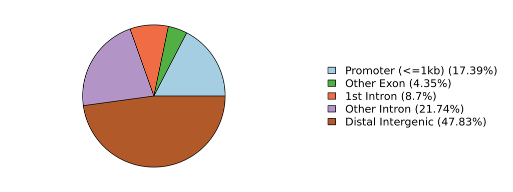

Figure 3.2 Composition of annotated peaks

Figure 3.3 Histogram of overlapping features under merged peaks, ranked by the number of peaks.

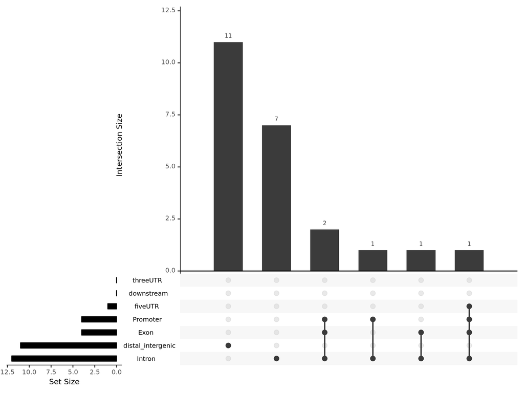

Figure 3.3 Overlapping genomic features by peak count

Figure 3.4 Distribution of genomic distance from peak summits to the nearest TSS.

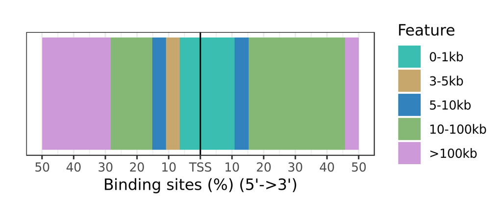

Figure 3.4 Distribution of genomic distances from each peak summit to the nearest TSS

Table 3.1 Summary of annotated differential peaks (up to 1000).

| seqnames | start | end | width | strand | Conc | Conc_Fetal.Dual.2m1 | Conc_Fetal.LAP.2m1 | Fold | p.value | FDR | annotation | geneStart | geneEnd | geneLength | geneStrand | geneId | transcriptId | distanceToTSS | gene_symbol | gene_name | gene_biotype | description |
| --- | --- | --- | --- | --- | --- | --- | --- | --- | --- | --- | --- | --- | --- | --- | --- | --- | --- | --- | --- | --- | --- | --- |
| 19 | 54191700 | 54192795 | 1096 | * | 4.79 | 5.71 | 1.67 | 4.03 | 2.45e-14 | 5.05e-12 | Intron (ENSRNOT00000023721/ENSRNOG00000017646, intron 2 of 3) | 54173971 | 54174387 | 417 | 2 | ENSRNOG00000038412 | ENSRNOT00000058502 | -17313 |  | AC118833.1 | protein_coding |  |
| 17 | 57815330 | 57816586 | 1257 | * | 5.28 | 6.08 | 3.3 | 2.79 | 2.07e-09 | 2.13e-07 | Promoter (&lt;=1kb) | 57814539 | 57816256 | 1718 | 2 | ENSRNOG00000045919 | ENSRNOT00000051570 | 0 | LOC103694120 | LOC103694120 | protein_coding | isopentenyl-diphosphate delta-isomerase 2-like [Source:RGD Symbol;Acc:9352023] |
| 1 | 148642883 | 148644099 | 1217 | * | 6.61 | 7.34 | 5.04 | 2.3 | 2.08e-08 | 1.43e-06 | Distal Intergenic | 148424977 | 148443358 | 18382 | 2 | ENSRNOG00000050401 | ENSRNOT00000072973 | -199525 | Vbp1 | Vbp1 | protein_coding | VHL binding protein 1 [Source:RGD Symbol;Acc:1590535] |
| 1 | 162369705 | 162370497 | 793 | * | 5.22 | 5.88 | 3.94 | 1.95 | 2.01e-05 | 0.00103 | Promoter (&lt;=1kb) | 162369801 | 162376023 | 6223 | 1 | ENSRNOG00000012383 | ENSRNOT00000016509 | 0 | Ndufc2 | Ndufc2 | protein_coding | NADH:ubiquinone oxidoreductase subunit C2 [Source:RGD Symbol;Acc:1307511] |
| 2 | 151057434 | 151058313 | 880 | * | 3.9 | 4.66 | 2.15 | 2.51 | 3.2e-05 | 0.00132 | Distal Intergenic | 151289736 | 151314629 | 24894 | 2 | ENSRNOG00000052971 | ENSRNOT00000087518 | 256316 |  | AABR07010777.1 | lincRNA |  |
| 1 | 50680964 | 50682993 | 2030 | * | 4 | 2.2 | 4.78 | -2.59 | 5.59e-05 | 0.00192 | Distal Intergenic | 50828134 | 50931579 | 103446 | 1 | ENSRNOG00000048297 | ENSRNOT00000089149 | -145141 | LOC108348175 | LOC108348175 | protein_coding | protein quaking-like [Source:RGD Symbol;Acc:11514364] |
| 9 | 113916582 | 113919063 | 2482 | * | 6.78 | 7.28 | 6.01 | 1.27 | 0.000128 | 0.00378 | Promoter (&lt;=1kb) | 113918858 | 113936860 | 18003 | 1 | ENSRNOG00000053306 | ENSRNOT00000091398 | 0 | Washc1 | Washc1 | protein_coding | WASH complex subunit 1 [Source:RGD Symbol;Acc:1310196] |
| 16 | 21899300 | 21900093 | 794 | * | 3.53 | 2.07 | 4.24 | -2.18 | 0.000518 | 0.0125 | Distal Intergenic | 21807191 | 21807526 | 336 | 2 | ENSRNOG00000055634 | ENSRNOT00000078775 | -91774 |  | AABR07024908.1 | processed_pseudogene |  |
| 14 | 46599338 | 46600353 | 1016 | * | 4.81 | 3.8 | 5.4 | -1.6 | 0.000548 | 0.0125 | Distal Intergenic | 46588411 | 46593828 | 5418 | 2 | ENSRNOG00000048268 | ENSRNOT00000071572 | -5510 |  | AABR07015067.1 | protein_coding |  |
| 6 | 93303468 | 93304700 | 1233 | * | 4.11 | 2.73 | 4.8 | -2.07 | 0.000845 | 0.0174 | Intron (ENSRNOT00000009610/ENSRNOG00000007329, intron 1 of 13) | 93281408 | 93358840 | 77433 | 1 | ENSRNOG00000007329 | ENSRNOT00000009610 | 22060 | Frmd6 | Frmd6 | protein_coding | FERM domain containing 6 [Source:RGD Symbol;Acc:727810] |

[output cut: 13 more lines]

- Azenta Life Sciences
- Next Generation Sequencing
- Email: ngs@azenta.com
- Phone: 908-222-0711 ext 1